# 4<sup>th</sup> exercise

Here I’m and it’s (again) 10pm on Sunday evening/night. Let’s get started! I have numbered the exercise sections to help you to follow my diary. Because you are reading this, I have maneged to done the first part of the exercise :)

### 2<sup>nd</sup> part

This time I’m analyzing data called *Boston* form the *Mass* library. It about housing values in suburbs of Boston. It includes lot of different kind of economical and social data about land usage, criminal rates, employment, and accessibility. More about the data set can be found ([here](https://stat.ethz.ch/R-manual/R-devel/library/MASS/html/Boston.html))

### 3<sup>rd</sup> part

I’ll use ggpairs to show overview of data:

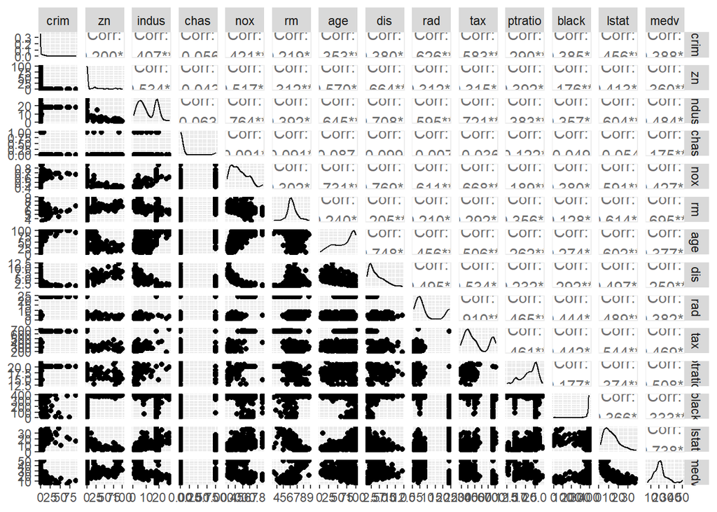

Summary of Boston suburbs

It’s seems there are lot of correlations between variables, which implies that studied variables will separate suburbs from each other. For example: Median value of owner-occupied homes has inverse corralation with crimes. Distributions are (surprise) quite clustered. Correlation plot looks following:

```
##          crim    zn indus  chas   nox    rm   age   dis   rad   tax ptratio
## crim     1.00 -0.20  0.41 -0.06  0.42 -0.22  0.35 -0.38  0.63  0.58    0.29
## zn      -0.20  1.00 -0.53 -0.04 -0.52  0.31 -0.57  0.66 -0.31 -0.31   -0.39
## indus    0.41 -0.53  1.00  0.06  0.76 -0.39  0.64 -0.71  0.60  0.72    0.38
## chas    -0.06 -0.04  0.06  1.00  0.09  0.09  0.09 -0.10 -0.01 -0.04   -0.12
## nox      0.42 -0.52  0.76  0.09  1.00 -0.30  0.73 -0.77  0.61  0.67    0.19
## rm      -0.22  0.31 -0.39  0.09 -0.30  1.00 -0.24  0.21 -0.21 -0.29   -0.36
## age      0.35 -0.57  0.64  0.09  0.73 -0.24  1.00 -0.75  0.46  0.51    0.26
## dis     -0.38  0.66 -0.71 -0.10 -0.77  0.21 -0.75  1.00 -0.49 -0.53   -0.23
## rad      0.63 -0.31  0.60 -0.01  0.61 -0.21  0.46 -0.49  1.00  0.91    0.46
## tax      0.58 -0.31  0.72 -0.04  0.67 -0.29  0.51 -0.53  0.91  1.00    0.46
## ptratio  0.29 -0.39  0.38 -0.12  0.19 -0.36  0.26 -0.23  0.46  0.46    1.00
## black   -0.39  0.18 -0.36  0.05 -0.38  0.13 -0.27  0.29 -0.44 -0.44   -0.18
## lstat    0.46 -0.41  0.60 -0.05  0.59 -0.61  0.60 -0.50  0.49  0.54    0.37
## medv    -0.39  0.36 -0.48  0.18 -0.43  0.70 -0.38  0.25 -0.38 -0.47   -0.51
##         black lstat  medv
## crim    -0.39  0.46 -0.39
## zn       0.18 -0.41  0.36
## indus   -0.36  0.60 -0.48
## chas     0.05 -0.05  0.18
## nox     -0.38  0.59 -0.43
## rm       0.13 -0.61  0.70
## age     -0.27  0.60 -0.38
## dis      0.29 -0.50  0.25
## rad     -0.44  0.49 -0.38
## tax     -0.44  0.54 -0.47
## ptratio -0.18  0.37 -0.51
## black    1.00 -0.37  0.33
## lstat   -0.37  1.00 -0.74
## medv     0.33 -0.74  1.00
```

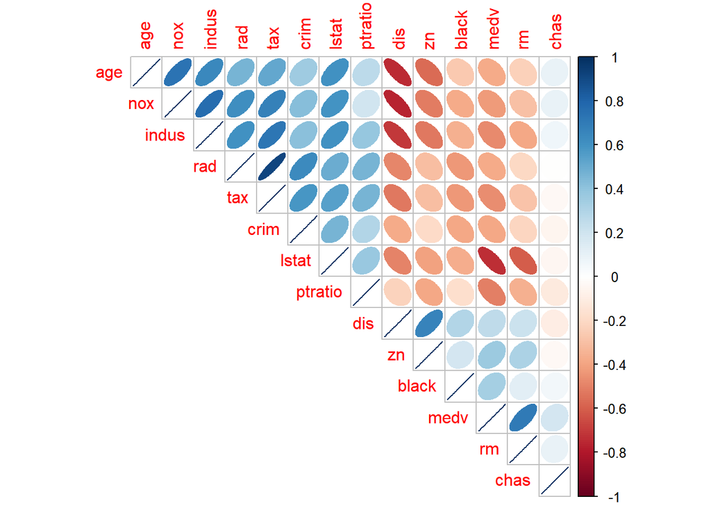

Correlation plot of Boston dataset

It seems that there are some very intuitive correlations:

- like accessibility to radial highways (*rad*) correlates positively with ull-value property-tax rate (*tax*)
- Lower status (lower education of adults, *lstat*) has a negative correlations with number of rooms in dwelling/flat (*rm*)

### 4<sup>th</sup> part

Scaling can be done easily with *scale* function. It will calculate difference of variable value and the mean, and then divided by standard deviation of the variable: $scaled(x)=\frac{x-\bar{x}}{sd(x)}$

What *scale* function does: Variable’s values are scattered around the mean, *scale* function shifts data around zero and the distance from the mean/zero is scaled with standard deviation. This is seems very logical way to scale. After the scale, mean of the all data will be 0 and 1 standard deviation will be 1 :D.

I’m bit worried about this, because distributions did not look normally distributed. *Scale* function will change the distributions and I’m curious if someone could tell me more about this..

In this case, all variables are numerical so no additional parameters needed for *scale* function call:

```r
boston_scaled <- scale(Boston)
summary(boston_scaled)
```

```
##       crim                 zn               indus              chas
##  Min.   :-0.419367   Min.   :-0.48724   Min.   :-1.5563   Min.   :-0.2723
##  1st Qu.:-0.410563   1st Qu.:-0.48724   1st Qu.:-0.8668   1st Qu.:-0.2723
##  Median :-0.390280   Median :-0.48724   Median :-0.2109   Median :-0.2723
##  Mean   : 0.000000   Mean   : 0.00000   Mean   : 0.0000   Mean   : 0.0000
##  3rd Qu.: 0.007389   3rd Qu.: 0.04872   3rd Qu.: 1.0150   3rd Qu.:-0.2723
##  Max.   : 9.924110   Max.   : 3.80047   Max.   : 2.4202   Max.   : 3.6648
##       nox                rm               age               dis
##  Min.   :-1.4644   Min.   :-3.8764   Min.   :-2.3331   Min.   :-1.2658
##  1st Qu.:-0.9121   1st Qu.:-0.5681   1st Qu.:-0.8366   1st Qu.:-0.8049
##  Median :-0.1441   Median :-0.1084   Median : 0.3171   Median :-0.2790
##  Mean   : 0.0000   Mean   : 0.0000   Mean   : 0.0000   Mean   : 0.0000
##  3rd Qu.: 0.5981   3rd Qu.: 0.4823   3rd Qu.: 0.9059   3rd Qu.: 0.6617
##  Max.   : 2.7296   Max.   : 3.5515   Max.   : 1.1164   Max.   : 3.9566
##       rad               tax             ptratio            black
##  Min.   :-0.9819   Min.   :-1.3127   Min.   :-2.7047   Min.   :-3.9033
##  1st Qu.:-0.6373   1st Qu.:-0.7668   1st Qu.:-0.4876   1st Qu.: 0.2049
##  Median :-0.5225   Median :-0.4642   Median : 0.2746   Median : 0.3808
##  Mean   : 0.0000   Mean   : 0.0000   Mean   : 0.0000   Mean   : 0.0000
##  3rd Qu.: 1.6596   3rd Qu.: 1.5294   3rd Qu.: 0.8058   3rd Qu.: 0.4332
##  Max.   : 1.6596   Max.   : 1.7964   Max.   : 1.6372   Max.   : 0.4406
##      lstat              medv
##  Min.   :-1.5296   Min.   :-1.9063
##  1st Qu.:-0.7986   1st Qu.:-0.5989
##  Median :-0.1811   Median :-0.1449
##  Mean   : 0.0000   Mean   : 0.0000
##  3rd Qu.: 0.6024   3rd Qu.: 0.2683
##  Max.   : 3.5453   Max.   : 2.9865
```

```r
boston_scaled <- as.data.frame(boston_scaled)
```

Then I’ll follow strickly the datacamp example, because I don’t have much imagination to improvise about this part. Following steps are mechanical and no words needed. First *crime* variable is “split” by it’s quantiles (= it’s divided into equal-size, adjacent, subgroups). Then quantiles are named and old variable *crim* is replaced by categorized variable *crime*:

```r
summary(boston_scaled$crim)
```

```
##      Min.   1st Qu.    Median      Mean   3rd Qu.      Max.
## -0.419367 -0.410563 -0.390280  0.000000  0.007389  9.924110
```

```r
bins <- quantile(boston_scaled$crim)
bins
```

```
##           0%          25%          50%          75%         100%
## -0.419366929 -0.410563278 -0.390280295  0.007389247  9.924109610
```

```r
crime <- cut(boston_scaled$crim, breaks = bins, include.lowest = TRUE, labels = c("low", "med_low", "med_high", "high"))
table(crime)
```

```
## crime
##      low  med_low med_high     high
##      127      126      126      127
```

```r
boston_scaled <- dplyr::select(boston_scaled, -crim)
boston_scaled <- data.frame(boston_scaled, crime)
```

Next, 80 percent of data will be training data and the rest will be test data.

```r
n <- nrow(boston_scaled)
ind <- sample(n,  size = n * 0.8)
train <- boston_scaled[ind,]
test <- boston_scaled[-ind,]
correct_classes <- test$crime
```

### 5<sup>th</sup> part

```r
lda.fit <- lda(crime ~ ., data = train)

# print the lda.fit object
lda.fit
```

```
## Call:
## lda(crime ~ ., data = train)
##
## Prior probabilities of groups:
##       low   med_low  med_high      high
## 0.2500000 0.2425743 0.2524752 0.2549505
##
## Group means:
##                  zn      indus       chas        nox         rm        age
## low       1.0174926 -0.8916417 -0.1164043 -0.9029239  0.3910687 -0.8913942
## med_low  -0.1026585 -0.2650311 -0.1116311 -0.5595464 -0.1213709 -0.3264497
## med_high -0.3846714  0.1862915  0.1522602  0.4157616  0.1570779  0.3966517
## high     -0.4872402  1.0149946 -0.0812077  1.0335144 -0.3858023  0.8189764
##                 dis        rad        tax     ptratio       black       lstat
## low       0.9156451 -0.6964601 -0.7414386 -0.45097009  0.37399681 -0.74818922
## med_low   0.3668660 -0.5353753 -0.3976742 -0.05063187  0.30760777 -0.12987579
## med_high -0.3905862 -0.4245269 -0.3209388 -0.26384954  0.06153609  0.03260287
## high     -0.8511277  1.6596029  1.5294129  0.80577843 -0.79300447  0.87487263
##                 medv
## low       0.50477206
## med_low  -0.01566045
## med_high  0.16741603
## high     -0.66586921
##
## Coefficients of linear discriminants:
##                 LD1          LD2         LD3
## zn       0.15317385  0.725908079 -1.10067565
## indus    0.05025438 -0.161573181  0.07676983
## chas    -0.10990738 -0.039068929  0.04988832
## nox      0.26663766 -0.883931718 -1.25982145
## rm      -0.14077463 -0.203713710 -0.13394513
## age      0.20796310 -0.192885749 -0.07515966
## dis     -0.09958990 -0.246719398  0.27435952
## rad      3.73238909  0.951180838 -0.52822726
## tax     -0.01107511 -0.005193381  1.19367573
## ptratio  0.16815170 -0.058826164 -0.32577100
## black   -0.13879498  0.001221668  0.10968924
## lstat    0.17156419 -0.329821665  0.25895198
## medv     0.18927572 -0.393945736 -0.16023905
##
## Proportion of trace:
##    LD1    LD2    LD3
## 0.9556 0.0329 0.0116
```

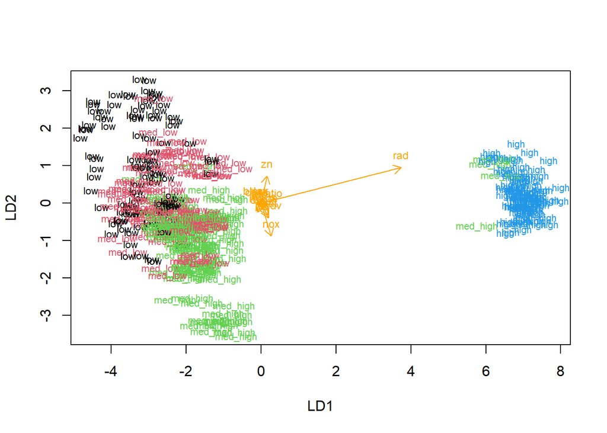

```r
lda.arrows <- function(x, myscale = 1, arrow_heads = 0.1, color = "orange", tex = 0.75, choices = c(1,2)){
  heads <- coef(x)
  arrows(x0 = 0, y0 = 0,
         x1 = myscale * heads[,choices[1]],
         y1 = myscale * heads[,choices[2]], col=color, length = arrow_heads)
  text(myscale * heads[,choices], labels = row.names(heads),
       cex = tex, col=color, pos=3)
}

# target classes as numeric
classes <- as.numeric(train$crime)

# plot the lda results
plot(lda.fit, dimen = 2, col = classes, pch = classes)
lda.arrows(lda.fit, myscale = 1)
```

### 6<sup>th</sup> part

```r
test <- dplyr::select(test, -crime)
# predict classes with test data
lda.pred <- predict(lda.fit, newdata = test)

# cross tabulate the results


table(correct = correct_classes, predicted = lda.pred$class)
```

```
##           predicted
## correct    low med_low med_high high
##   low       12      12        2    0
##   med_low    5      20        3    0
##   med_high   0       6       16    2
##   high       0       0        1   23
```

```r
data("Boston")
scaled2<-scale(Boston)

dist_eu <- dist(scaled2)

# look at the summary of the distances
summary(dist_eu)
```

```
##    Min. 1st Qu.  Median    Mean 3rd Qu.    Max.
##  0.1343  3.4625  4.8241  4.9111  6.1863 14.3970
```

```r
# manhattan distance matrix
dist_man <- dist(scaled2, method = 'manhattan')

summary(dist_man)
```

```
##    Min. 1st Qu.  Median    Mean 3rd Qu.    Max.
##  0.2662  8.4832 12.6090 13.5488 17.7568 48.8618
```

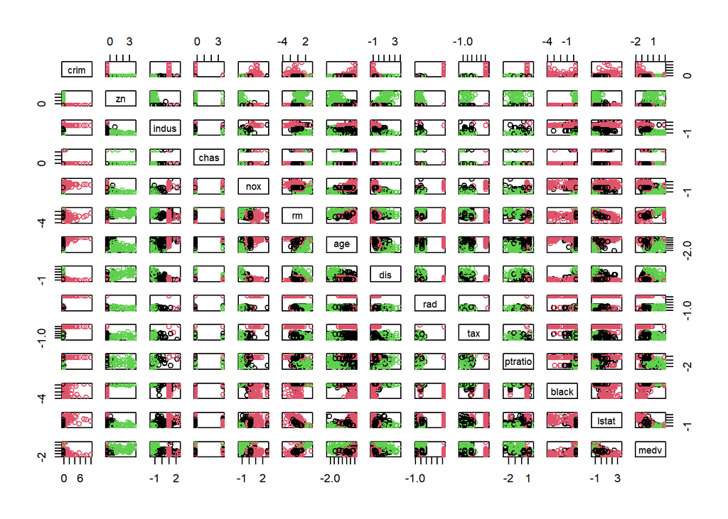

```r
# k-means clustering
km <-kmeans(scaled2, centers = 3)

scaled2 <- as.data.frame(scaled2)

# plot the Boston data set with clusters
pairs(scaled2, col = km$cluster)
```

It look bit wierd. Let’s see can we use more clusters to get better fit.

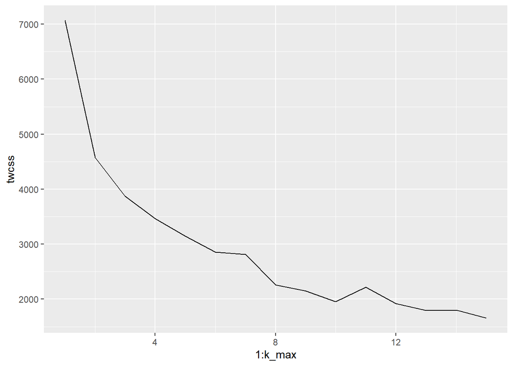

```r
set.seed(123)

k_max <- 15

# calculate the total within sum of squares
twcss <- sapply(1:k_max, function(k){kmeans(scaled2, k)$tot.withinss})

# visualize the results
qplot(x = 1:k_max, y = twcss, geom = 'line')
```

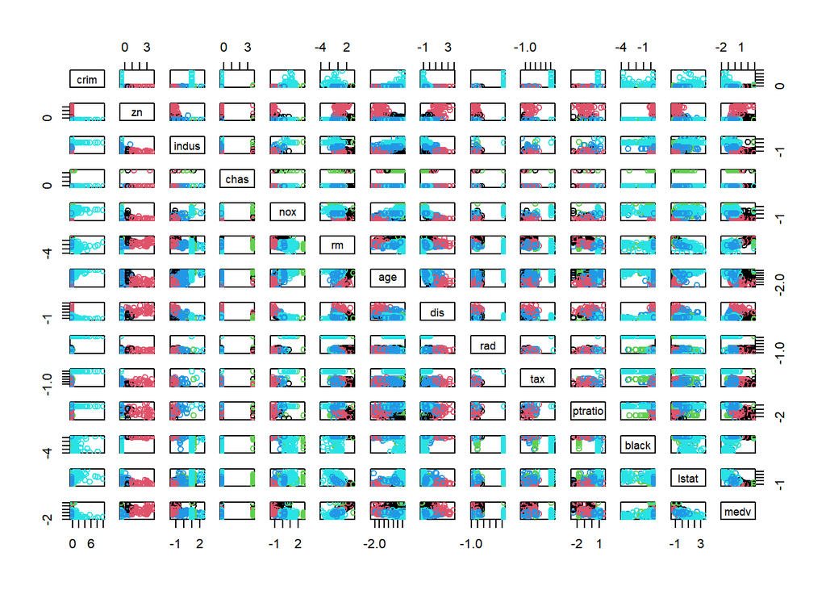

```r
# k-means clustering
km <-kmeans(scaled2, centers = 5)

# plot the Boston dataset with clusters
pairs(scaled2, col = km$cluster)
```

Well, it’s 01:00 am and time to go sleep!